# Logistic Regression Model for per-school Student Teacher Race Match

Julia Tucher

5/13/2021

In this code sample, submitted in partial completion of my senior honors thesis at Williams College, I use an original metric for teacher-student race match along with a number of school descriptor variables provided by the California Department of Education (CDE). Race match refers to a student-teacher pairing where student and teacher share a racial-ethnic background. The thesis was motivated by a body of education research indicating the benefits of race match on student outcomes, student self-perception, and teacher expectations. The goal of this aspect of the project is to build a logistic regression model, with proportion of same-race teachers as the response variable, to examine trends in student-teacher race match. Specifically, I am interested to see how race match compares across racial/ethnic groups; the demographic proportions of the school; and a school’s charter status, instruction level, and enrollment count.

First, I import relevant libraries and the data set. The data, which I compiled from a number of CDE sources, is per grade level instead of per school. Furthermore, match values represent the average number of same-race teachers a student has, instead of the proportion of their teachers that are a race match ($\text{Match Proportion} = \frac{\text{Match Value}}{\text{Total Teachers}}$). So in this R chunk, after importing, we aggregate at the school level and convert to proportions, as well as getting rid of extraneous predictors.

```r
library(tidyverse)
library(caret)
library(aod)
library(car)
library(Metrics)

# import data (each observation is per school, per grade, per racial-ethnic group)
grades <- read.csv("data.csv")

# multiply by grade-wise enrollment to get total matches and mismatches at school level
grades_interaction <- grades %>%
  mutate(MatchValue = ifelse(EnrollCount != 0, MatchValue * EnrollCount, 0),
         MismatchValue = ifelse(EnrollCount != 0, MismatchValue * EnrollCount, 0))

# aggregate by summing across grade levels, scaled by enrollment
schools <- aggregate(formula=cbind(EnrollCount, MatchValue, MismatchValue, TotalTeacher) ~ CDS_CODE +
                       DistrictCode + SchoolCode + COUNTY + DISTRICT +
                       SCHOOL + GradeCategory + SchoolType + EthnicGroup + Elementary, data=grades_interaction, FUN=sum)

# divide by total school enrollment, then calculate enrollment proportion and match proportion at school level
schools <- schools %>%
  mutate(MatchValue = ifelse(EnrollCount != 0, MatchValue / EnrollCount, NA),
         MismatchValue = ifelse(EnrollCount != 0, MismatchValue / EnrollCount, NA),
         TotalTeacher = MatchValue + MismatchValue) %>%
  group_by(CDS_CODE) %>%
  mutate(EnrollTotal = sum(EnrollCount)) %>%
  ungroup() %>%
  mutate(EnrollProportionSameRace = EnrollCount / EnrollTotal,
         MatchProp = MatchValue / TotalTeacher) %>%
  select(-c(CDS_CODE, EnrollCount)) %>%
  na.omit() %>%
  as.data.frame()
```

Now that our data is aggregated at the school level, includes a response variable in the form of a proportion, and has the desired predictor variables, set the encoding scheme and view the first few rows of the data set.

```r
# set coding scheme for ethnic group variable
schools$EthnicGroup = as.factor(schools$EthnicGroup)
contrasts(schools$EthnicGroup) <- contr.sum(levels(schools$EthnicGroup))
colnames(contrasts(schools$EthnicGroup)) <- head(levels(schools$EthnicGroup), -1)

# peek at data
head(schools)
```

```
##   DistrictCode SchoolCode         COUNTY                   DISTRICT
## 1      1964246     126003    LOS ANGELES Antelope Valley Union High
## 2      3667736     116723 SAN BERNARDINO       Helendale Elementary
## 3      1964733     118588    LOS ANGELES        Los Angeles Unified
## 4      1964733     121285    LOS ANGELES        Los Angeles Unified
## 5      1964733     108894    LOS ANGELES        Los Angeles Unified
## 6      1964733     117606    LOS ANGELES        Los Angeles Unified
##                                               SCHOOL GradeCategory SchoolType
## 1                   Academies of the Antelope Valley          HIGH    Charter
## 2                 Academy of Careers and Exploration          HIGH    Charter
## 3      Alain Leroy Locke College Preparatory Academy          HIGH    Charter
## 4 Alliance Cindy and Bill Simon Technology Academy H          HIGH    Charter
## 5  Alliance Judy Ivie Burton Technology Academy High          HIGH    Charter
## 6 Alliance Leichtman-Levine Family Foundation Enviro          HIGH    Charter
##       EthnicGroup Elementary MatchValue MismatchValue TotalTeacher EnrollTotal
## 1 American Indian      FALSE  0.0000000      6.333333     6.333333         484
## 2 American Indian      FALSE  0.0000000      3.000000     3.000000         324
## 3 American Indian      FALSE  0.3333333      4.333333     4.666667        1393
## 4 American Indian      FALSE  0.0000000      6.000000     6.000000         508
## 5 American Indian      FALSE  0.0000000      5.000000     5.000000         604
## 6 American Indian      FALSE  0.0000000      3.500000     3.500000         484
##   EnrollProportionSameRace  MatchProp
## 1              0.006198347 0.00000000
## 2              0.009259259 0.00000000
## 3              0.004307251 0.07142857
## 4              0.001968504 0.00000000
## 5              0.001655629 0.00000000
## 6              0.004132231 0.00000000
```

Next, set the seed and partition the data into training and testing data, for later model validation.

```r
set.seed(100)  # for reproducability

training.samples <- schools$MatchProp %>% createDataPartition(p = 0.8, list = FALSE)
train.data  <- schools[training.samples, ]
test.data <- schools[-training.samples, ]
```

Before building the model, we must check the five assumptions of logistic regression:

1. Binary logistic regression requires outcome variable to be binary. Here, Match is a success and Mismatch is a failure. Match proportion is the proportion of trails (total teachers) that are successes.
2. Observations are independent.
3. Little to no multicolinearity among independent variables.

```r
cor(schools[,c("EnrollProportionSameRace", "TotalTeacher", "EnrollTotal")])
```

```
##                          EnrollProportionSameRace TotalTeacher EnrollTotal
## EnrollProportionSameRace               1.00000000  -0.01658049 -0.04950749
## TotalTeacher                          -0.01658049   1.00000000  0.41177377
## EnrollTotal                           -0.04950749   0.41177377  1.00000000
```

4. Linearity of independent variables and log odds. We isolate the quantitative predictors and plot them against the log odds of our response variable to assess linearity. We note that while same-race enrollment proportion has a weak, positive linear relationship, enrollment total and total teacher have nearly no linear relationship. Thus, we expect only the first predictor to be a statistically relevant predictor.

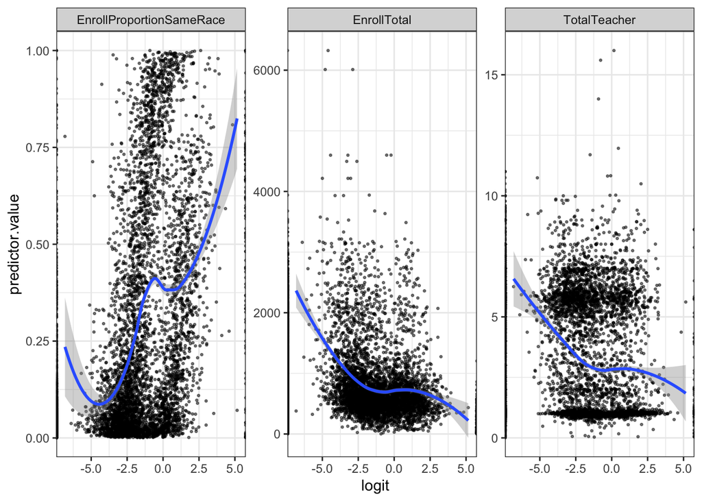

```r
# Select only numeric predictors
predictors <- c("EnrollProportionSameRace", "TotalTeacher", "EnrollTotal")
mydata <- test.data[, predictors]

# Bind the logit and tidying the data for plot
mydata <- mydata %>%
  mutate(logit = log(test.data$MatchProp/(1-test.data$MatchProp))) %>%
  gather(key = "predictors", value = "predictor.value", -logit)

# plot predictors against logit
ggplot(mydata, aes(logit, predictor.value)) +
  geom_point(size = 0.5, alpha = 0.5) +
  geom_smooth(method = "loess") +
  theme_bw() +
  facet_wrap(~predictors, scales = "free_y")
```

5. Large sample size: $n = 46321$.

```r
nrow(train.data)
```

```
## [1] 46321
```

```r
# view all the exponentiated coefficients
exp(coefficients(model.int))
```

```
##                                          (Intercept)
##                                           0.02563819
##                             EnrollProportionSameRace
##                                          83.93138381
##                                       ElementaryTRUE
##                                           0.91080472
##                                        SchoolTypeTPS
##                                           0.91829675
##                           EthnicGroupAmerican Indian
##                                           0.14123239
##                                     EthnicGroupAsian
##                                           2.82461567
##                                     EthnicGroupBlack
##                                           1.49196918
##                                  EthnicGroupFilipino
##                                           0.47915869
##                                  EthnicGroupHispanic
##                                           2.57622699
##                          EthnicGroupPacific Islander
##                                           0.12228959
##                               EthnicGroupTwo or More
##                                           0.44142214
##              EnrollProportionSameRace:ElementaryTRUE
##                                           1.53044525
##               EnrollProportionSameRace:SchoolTypeTPS
##                                           1.95690149
##  EnrollProportionSameRace:EthnicGroupAmerican Indian
##                                           0.78209368
##            EnrollProportionSameRace:EthnicGroupAsian
##                                           0.15411957
##            EnrollProportionSameRace:EthnicGroupBlack
##                                           2.04942800
##         EnrollProportionSameRace:EthnicGroupFilipino
##                                          15.11367025
##         EnrollProportionSameRace:EthnicGroupHispanic
##                                           0.10907404
## EnrollProportionSameRace:EthnicGroupPacific Islander
##                                          22.39467436
##      EnrollProportionSameRace:EthnicGroupTwo or More
##                                           0.60632800
##             SchoolTypeTPS:EthnicGroupAmerican Indian
##                                           1.83043579
##                       SchoolTypeTPS:EthnicGroupAsian
##                                           0.65774340
##                       SchoolTypeTPS:EthnicGroupBlack
##                                           0.76954304
##                    SchoolTypeTPS:EthnicGroupFilipino
##                                           0.97702913
##                    SchoolTypeTPS:EthnicGroupHispanic
##                                           0.67097042
##            SchoolTypeTPS:EthnicGroupPacific Islander
##                                           1.26258286
##                 SchoolTypeTPS:EthnicGroupTwo or More
##                                           0.89425133
```

To assess model fit, we can view the McFadden’s R-squared, which estimates the proportion of total variance in the dataset accounted for by this model. Here, we note a relatively high value of 0.625.

```r
# create null model to compare our model to
null.model <- glm(MatchProp~1, data=train.data, family=binomial(logit), weights=TotalTeacher)

# McFadden's R2
mcfadden <- 1 - logLik(model.int)/logLik(null.model)
mcfadden
```

```
## 'log Lik.' 0.6252264 (df=27)
```

To further assess the model, and determine its predictive capabilities, we test it on the holdout data. Then, we examine the model’s root mean squared error and Pearson’s r-squared for these predictions. The rmse value means that, on average, the true value is within 11.74 percentage points of the predicted percentage. The r-squared coefficient of 0.8 indicates that the model performed well on holdout data.

```r
# Make predictions
pred.data <- mutate(test.data, Preds = predict(model.int, test.data, type = "response"))

# Model accuracy
rmse <- rmse(pred.data$MatchProp, pred.data$Preds)
r2 <- cor(pred.data$MatchProp, pred.data$Preds)^2
rmse
```

```
## [1] 0.1174069
```

```r
r2
```

```
## [1] 0.8000715
```

Finally, we visualize the model’s logistic curve plotted on our dataset. We facet results by racial/ethnic group, plotting race match proportion on enrollment proportion. Color and linetype are used to depict school classification.

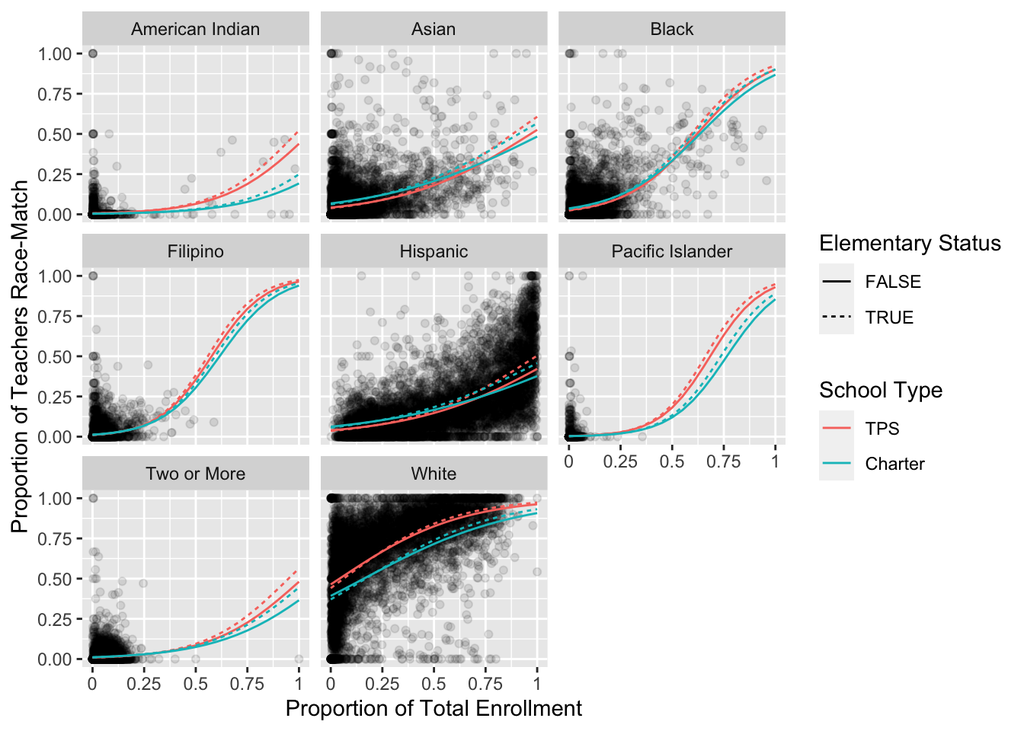

```r
# create points for curve using full range of each predictor's values
alldata = expand.grid(EnrollProportionSameRace=seq(0,1,0.05), SchoolType=c("TPS", "Charter"),
                      Elementary=c(TRUE, FALSE), EthnicGroup=levels(train.data$EthnicGroup),
                      TotalTeacher=mean(schools$TotalTeacher),
                      EnrollTotal=mean(schools$EnrollTotal)) %>%
  mutate(Prediction = predict(model.int, newdata=., type="response"))

# plot
ggplot() +
  geom_point(data=train.data, aes(EnrollProportionSameRace, MatchProp), alpha = 0.1) +
  geom_line(data=alldata, aes(x=EnrollProportionSameRace, y=Prediction, color=SchoolType,
                              linetype=Elementary)) +
  facet_wrap(facets=vars(EthnicGroup)) +
  labs(x="Proportion of Total Enrollment", y = "Proportion of Teachers Race-Match") +
  scale_x_continuous(breaks=seq(0, 1, 0.25), labels=seq(0, 1, 0.25)) +
  guides(color=guide_legend(title="School Type"), linetype=guide_legend(title="Elementary Status"))
```